# ME MA outliers

2019-10-21

In response to reviewer 1.

```r
ME_DATA_PATH <- here("data/0_metaanalysis_data.csv")
ma_raw <- read_csv(ME_DATA_PATH) %>%
  select(1:4, 6:8, 10:16, 18,19,21, 27:29, 31:34, 48:50, 59) %>%
  mutate_if(is.character, as.factor)

AVG_MONTH <- 30.43688
ma_c <- ma_raw %>%
  filter(!is.na(d_calc)) %>%
  mutate(mean_age = mean_age_1/AVG_MONTH,
         year = as.numeric(str_sub(short_cite, -5, -2)),
         condition_type = as.factor(ifelse(infant_type == "typical" & ME_trial_type == "FN", "TFN",
                                 ifelse(infant_type == "typical" & ME_trial_type == "NN", "TNN",
                                        as.character(infant_type))))) %>%
  filter(mean_age < 144)   #  (12 yo), excludes MR population
  # filter(!(study_ID %in% c("williams2009", "frank1999"))) # for checking that holds when exclude dissertations [it does]
```

# Outliers

```r
overall_mean <- mean(ma_c$d_calc)
overall_sd <- sd(ma_c$d_calc)

plus2 <- overall_mean + (2*(overall_sd))
minus2 <- overall_mean - (2*(overall_sd))

plus3 <- overall_mean + (3*(overall_sd))
minus3 <- overall_mean - (3*(overall_sd))

twosd_outliers <- ma_c %>%
  filter(d_calc > plus2 | d_calc < minus2) %>%
  data.frame()

threesd_outliers <- ma_c %>%
  filter(d_calc > plus3 | d_calc < minus3) %>%
  data.frame()
```

There are 8 conditions that are 2sds beyond the mean; There are 3 conditions that are 3sds beyond the mean:

```r
kable(threesd_outliers)
```

| study_ID | short_cite | long_cite | peer_reviewed | expt_num | response_mode | dependent_measure | infant_type | infant_type2 | group_name_1 | n_1 | mean_age_1 | same_infant | x_1 | SD_1 | t | d | num_trials | object_stimulus | N_AFC | mean_production_vocab | ME_trial_type | lab_group | data_source | d_notes | d_calc | d_var_calc | es_method | mean_age | year | … |
| --- | --- | --- | --- | --- | --- | --- | --- | --- | --- | --- | --- | --- | --- | --- | --- | --- | --- | --- | --- | --- | --- | --- | --- | --- | --- | --- | --- | --- | --- | --- |
| estis2015 | Estis & Beverly (2015) | Estis, J. M., & Beverly, B. L. (2015). Children with SLI exhibit delays resolving ambiguous reference. Journal of child language, 42(1), 180-195. | yes | 1 | behavior | target_selection | NT | SLI | experimental | 8 | 2617.571 | 25 | 0.960 | 0.070 | NA | NA | 10 | objects | N_AFC-2 | NA | FN | estis | paper | NA | 6.571429 | 2.823980 | group_means_one | 85.99998 | 2015 | … |
| frank2016 | Frank et al. (2016) | Frank, M. C., Sugarman, E., Horowitz, A., Lewis, M. L., & Yurovsky, D. (2016). Using tablets to collect data from young children. Journal of Cognition and Development,17(1), 1-17. | yes | 1 | behavior | target_selection | typical | typical | experimental | 20 | 1636.320 | 39 | 0.970 | 0.060 | NA | 7.833333 | 8 | digital | N_AFC-2 | NA | FN | framkm | paper | NA | 7.833333 | 1.584028 | group_means_one | 53.76110 | 2016 | … |
| gollek2016 | Gollek & Doherty (2016) | Gollek, C.& Doherty, M.J. (2016). Metacognitive developments in word learning: Mutual exclusivity and theory of mind. Journal of Experimental Child Psychology. 148, 51-69. | yes | 3 | behavior | target_selection | typical | typical | disambiguation - younger | 15 | 1278.349 | 42 | 0.986 | 0.052 | NA | NA | 5 | objects | N_AFC-2 | NA | FN | gollek | paper | NA | 9.346154 | 2.978353 | group_means_one | 42.00000 | 2016 | … |

# Testing for heteroskedasticity

## Including outliers:

```r
model <- lm(d_calc ~ mean_age, data = ma_c, weights = n_1)
olsrr::ols_test_breusch_pagan(model)
```

```
##
##  Breusch Pagan Test for Heteroskedasticity
##  -----------------------------------------
##  Ho: the variance is constant
##  Ha: the variance is not constant
##
##                Data
##  ----------------------------------
##  Response : d_calc
##  Variables: fitted values of d_calc
##
##          Test Summary
##  -------------------------------
##  DF            =    1
##  Chi2          =    11.94575
##  Prob > Chi2   =    0.0005477213
```

```r
olsrr::ols_test_f(model)
```

```
##
##  F Test for Heteroskedasticity
##  -----------------------------
##  Ho: Variance is homogenous
##  Ha: Variance is not homogenous
##
##  Variables: fitted values of d_calc
##
##        Test Summary
##  --------------------------
##  Num DF     =    1
##  Den DF     =    144
##  F          =    3.12629
##  Prob > F   =    0.07915652
```

```r
model <- lm(d_calc ~ mean_age, data = ma_c  %>% filter(d_calc > plus3 | d_calc < minus3), weights = n_1)
olsrr::ols_test_breusch_pagan(model)
```

```
##
##  Breusch Pagan Test for Heteroskedasticity
##  -----------------------------------------
##  Ho: the variance is constant
##  Ha: the variance is not constant
##
##                Data
##  ----------------------------------
##  Response : d_calc
##  Variables: fitted values of d_calc
##
##         Test Summary
##  ----------------------------
##  DF            =    1
##  Chi2          =    0.1313952
##  Prob > Chi2   =    0.7169899
```

```r
olsrr::ols_test_f(model)
```

```
##
##  F Test for Heteroskedasticity
##  -----------------------------
##  Ho: Variance is homogenous
##  Ha: Variance is not homogenous
##
##  Variables: fitted values of d_calc
##
##       Test Summary
##  -------------------------
##  Num DF     =    1
##  Den DF     =    1
##  F          =    8.231854
##  Prob > F   =    0.2135048
```

# Main analysis excluding outliers

```r
ME_DATA_PATH <- here("data/0_metaanalysis_data.csv")
ma_raw <- read_csv(ME_DATA_PATH) %>%
  select(1:4, 6:8, 10:16, 18,19,21, 27:29, 31:34, 48:50, 59) %>%
  mutate_if(is.character, as.factor)

AVG_MONTH <- 30.43688
ma_c <- ma_raw %>%
  filter(!is.na(d_calc)) %>%
  mutate(mean_age = mean_age_1/AVG_MONTH,
         year = as.numeric(str_sub(short_cite, -5, -2)),
         condition_type = as.factor(ifelse(infant_type == "typical" & ME_trial_type == "FN", "TFN",
                                 ifelse(infant_type == "typical" & ME_trial_type == "NN", "TNN",
                                        as.character(infant_type))))) %>%
  filter(mean_age < 144)  %>% #  (12 yo), excludes MR population
  filter(d_calc < mean(.$d_calc) + (3*(sd(d_calc))), # exclude conditions 3 sd from mean
         d_calc > mean(.$d_calc) - (3*(sd(d_calc))))
  # filter(!(study_ID %in% c("williams2009", "frank1999"))) # for checking that holds when exclude dissertations [it does]
```

```r
get_MA_params <- function(this_condition_type, age_moderated, df) {

  if (this_condition_type == "grand"){
    this_data <- df
  } else {
      this_data  <- filter(df, condition_type == this_condition_type)
  }

  n = nrow(this_data)

  if (age_moderated){
      model <- rma.mv(d_calc ~ mean_age, V = d_var_calc,
                      random = ~ 1 | short_cite/same_infant,
                      method = "REML",
                      data = this_data)

      this_age_estimate <- model$b[2]
      this_age_estimate.cil <- model$ci.lb[2]
      this_age_estimate.cih <- model$ci.ub[2]
      this_age_z <- model$zval[2]
      this_age_p <- model$pval[2]

  } else {
      model <- rma.mv(d_calc, V = d_var_calc,
                      random = ~ 1 | short_cite/same_infant,
                      method = "REML",
                      data = this_data)

      this_age_estimate <- NA
      this_age_estimate.cil <- NA
      this_age_estimate.cih <- NA
      this_age_z <- NA
      this_age_p <- NA

  }

  params <- data.frame(condition_type = this_condition_type,
                       age_moderated = age_moderated,
                       n = n,
                       estimate = model$b[1],
                       estimate.cil = model$ci.lb[1],
                       estimate.cih = model$ci.ub[1],
                       z = model$zval[1],
                       p = model$pval[1],
                       age_estimate = this_age_estimate,
                       age_estimate.cil = this_age_estimate.cil,
                       age_estimate.cih = this_age_estimate.cih,
                       age_z = this_age_z,
                       age_p = this_age_p,
                       Q = model$QE,
                       Qp = model$QEp)
}

model_pairs <- expand.grid(condition_type = c("grand",
as.character(unique(ma_c$condition_type))),
                           age_moderated = c(TRUE, FALSE),
                           stringsAsFactors = F )

all_models <- map2_df(model_pairs$condition_type,
                      model_pairs$age_moderated,
                      get_MA_params, ma_c)

# tidy variables for printing in ms
mod_print <- all_models %>%
             mutate(esimate_print = round(estimate, 2),
                    CI_print = paste0(" [",
                                      round(estimate.cil, 2),
                                     ", ",
                                     round(estimate.cih, 2),
                                     "]"),
                   estimate_print_full = paste(esimate_print, CI_print),
                   z_print = round(z, 2),
                   p_print = round(p, 2),
                   p_print = ifelse(p_print <.001, "<.001", paste0("= ", p_print)),
                   age_estimate_print = round(age_estimate, 2),
                   age_CI_print = paste0(" [",
                                      round(age_estimate.cil, 2),
                                     ", ",
                                     round(age_estimate.cih, 2),
                                     "]"),
                   age_estimate_print_full = paste(age_estimate_print, age_CI_print),

                   age_z_print =  round(age_z, 2),
                   age_p_print =  round(age_p, 2),
                   age_p_print = ifelse(age_p_print <.001, "<.001",
                                        paste0("= ", age_p_print)),
                   Q_print = round(Q, 2),
                   Qp_print = round(Qp, 2),
                   Qp_print = ifelse(Qp_print <.001, "<.001", paste0("= ", Qp_print)))
```

```r
forest_model_data <- mod_print %>%
                          filter(!age_moderated) %>%
                          rename(model_name = condition_type) %>%
                          mutate(model_type = ifelse(model_name == "grand",
                                 "grand", "sub"),
                                 model_name = fct_relevel(model_name,
                                                          "TFN",
                                                          "TNN",
                                                          "multilingual",
                                                          "NT",
                                                          "grand"),
                                 model_name = fct_rev(model_name))

 breaks <- seq(-.25, 2.5, .25)
 labels <- as.character(breaks)
 labels[!(breaks%%1==0)] <- ''
 tick.sizes <- rep(.5, length(breaks))
 tick.sizes[(breaks%%1==0)] <- 1
```

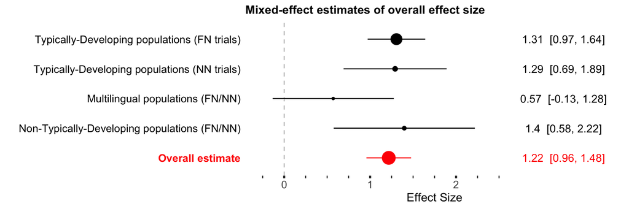

Mixed-effect effect size estimates for all conditions (red) and each of the four theoretically-relevant conditions in our sample. Ranges are 95 percent confidence intervals. Point size corresponds to sample size. FN = Familiar-Novel trials; NN = Novel-Novel trials.

```r
p1 <- ggplot(forest_model_data,
             aes(x = model_name,
                 y = estimate,
                 color = model_type)) +
  geom_vline(xintercept = 0) +
  geom_hline(yintercept = 0, linetype = "dashed", color = "grey") +
  geom_point(aes(size = n)) +
  geom_linerange(aes(ymin = estimate.cil,
                     ymax = estimate.cih)) +
  geom_text(aes(label = estimate_print_full, x = model_name, y = 3.25),
            size = 4) +
  coord_flip()

p1 <- p1 + scale_shape_manual(values = c(16, 15)) +
  scale_color_manual(values = c( '#FF0000', "#000000")) +
  scale_size_continuous(guide = FALSE) +
  scale_y_continuous(breaks = breaks,
                     labels = labels,
                     limits = c(-.25, 3.75),
                     name = "Effect Size") +
  scale_x_discrete(labels = c("NT" = "Non-Typically-Developing populations (FN/NN)",
                              "grand" = "Overall estimate",
                              "TFN" = "Typically-Developing populations (FN trials)",
                              "TNN" = "Typically-Developing populations (NN trials)",
                              "multilingual" = "Multilingual populations (FN/NN)"),
                   name = "") +
  ggtitle("Mixed-effect estimates of overall effect size")

p1 <- p1 +
  theme_bw() +
  theme(axis.line.y = element_blank(),
        panel.grid.major = element_blank(),
        panel.grid.minor = element_blank(),
        panel.border = element_blank(),
        panel.background = element_blank(),
        legend.position = "none",
        axis.ticks.x = element_line(size = tick.sizes),
        axis.ticks.y = element_blank(),
        axis.text.x = element_text(size = 11),
        axis.text.y = element_text(size = 11,
                                   colour = c('red', rep('black', 4)),
                                   face = c("bold", rep("plain", 4))),
        plot.title = element_text(size = 12, face = "bold"),
        axis.title = element_text(size = 12))
p1
```

The overall effect size for these conditions was 1.31 [0.97, 1.64], and reliably greater than zero (*p* <.001; Figure 1). The effect sizes contained considerable heterogeneity, however (*Q* = 765.97; *p* <.001).

```r
age <- mod_print %>%
  filter(age_moderated) %>%
  select(condition_type, age_estimate_print_full, age_z_print, age_p) %>%
  mutate(term = "age") %>%
  select(condition_type, term, everything()) %>%
  rename(estimate_print_full = age_estimate_print_full,
          z_print =  age_z_print,
          p = age_p)

intercept <- mod_print %>%
  filter(age_moderated) %>%
  select(condition_type, n, estimate_print_full, z_print, p) %>%
  mutate(term = "intercept")

print_age_table_data <- bind_rows(intercept, age) %>%
    arrange(condition_type) %>%
    select(condition_type, term, everything()) %>%
    mutate(p = ifelse(p < .01, "<.01", round(p, 2)))  %>%
    mutate(condition_type = ifelse(term == "age", "", condition_type)) %>%
    select(condition_type, n, everything()) %>%
    mutate(n = ifelse(is.na(n), "", n),
           condition_type = as.factor(condition_type),
          condition_type = fct_recode(condition_type,
                                      `Non-Typically-Developing populations (FN/NN)` = "NT",
           `Overall estimate` = "grand",
           `Typically-Developing populations (FN trials)`  = "TFN",
           `Typically-Developing populations (NN trials)` = "TNN",
           `Multilingual populations (FN/NN)` =   "multilingual"))

print_age_table_data <- print_age_table_data[c(1,2,7,8,9,10,3,4,5,6),]
colnames(print_age_table_data) <- c("Model", "n", "term", "estimate [CI]", "Z", "p")
```

```r
kable(print_age_table_data, caption = "Meta-analytic model parameters for model including age as a fixed effect. The first model (top) estimates effect sizes for all studies in our sample. The four subsequent models present separate models parameters for four separate conditions. Ranges are 95 percent confidence intervals.", small = T, note = "n = sample size (number of studies); FN = Familiar-Novel; NN = Novel-Novel.")
```

Meta-analytic model parameters for model including age as a fixed effect. The first model (top) estimates effect sizes for all studies in our sample. The four subsequent models present separate models parameters for four separate conditions. Ranges are 95 percent confidence intervals.

|  | Model | n | term | estimate [CI] | Z | p |
| --- | --- | --- | --- | --- | --- | --- |
| 1 | Overall estimate | 143 | intercept | 0.08 [-0.35, 0.5] | 0.35 | 0.72 |
| 2 |  |  | age | 0.03 [0.02, 0.04] | 5.99 | <.01 |
| 7 | Typically-Developing populations (FN trials) | 99 | intercept | -0.36 [-0.99, 0.27] | -1.11 | 0.27 |
| 8 |  |  | age | 0.05 [0.03, 0.07] | 5.66 | <.01 |
| 9 | Typically-Developing populations (NN trials) | 18 | intercept | 0.1 [-0.59, 0.8] | 0.29 | 0.77 |
| 10 |  |  | age | 0.02 [0.01, 0.04] | 3.83 | <.01 |
| 3 | Multilingual populations (FN/NN) | 12 | intercept | 0.05 [-0.78, 0.87] | 0.11 | 0.91 |
| 4 |  |  | age | 0.02 [0, 0.03] | 1.77 | 0.08 |
| 5 | Non-Typically-Developing populations (FN/NN) | 14 | intercept | -0.38 [-1.41, 0.64] | -0.74 | 0.46 |
| 6 |  |  | age | 0.03 [0.02, 0.05] | 4.27 | <.01 |

```r
age_vocab_corr <- ma_c %>%
  filter(condition_type == 'TFN') %>%
  do(tidy(cor.test(.$mean_age, .$mean_production_vocab)))

num_vocab_conditions <- ma_c %>%
  filter(condition_type == 'TFN',
         !is.na(mean_production_vocab)) %>%
  nrow()

age_vocab_model <- rma.mv(d_calc ~ mean_age + mean_production_vocab,
                          V = d_var_calc,
                      random = ~ 1 | short_cite/same_infant,
                      method = "REML",
                       data = filter(ma_c, condition_type == 'TFN'))

# df <- ma_c %>%
#   filter(condition_type == 'TFN') %>%
#   filter(!is.na(mean_production_vocab))
#
# ggplot(df, aes(x = mean_production_vocab, y = d_calc)) +
#   geom_point() +
#   geom_smooth(method = "lm")
#
# ggplot(df, aes(x = mean_age, y = d_calc)) +
#   geom_point() +
#   geom_smooth(method = "lm")

# age_vocab_model params
av_a_beta <- round(age_vocab_model$beta[2],2)
av_v_beta <- round(age_vocab_model$beta[3],4) # more digits because 0, if else
av_a_zval <- round(age_vocab_model$zval[2],2)
av_v_zval <- round(age_vocab_model$zval[3],2)
av_a_pval <- ifelse(round(age_vocab_model$pval[2],2)  < .0001,
                    "<.0001", paste0(" = ", round(age_vocab_model$pval[2],2)))
av_v_pval <- ifelse(round(age_vocab_model$pval[3],2)  < .0001,
                    "<.0001", paste0(" = ", round(age_vocab_model$pval[3],2)))
```

These analyses confirm that the ME effect is robust, and associated with a relatively large effect size (*d* = 1.31 [0.97, 1.64]). They also suggest that the magnitude of the effect strengthens over development. Vocabulary size, though correlated with age, does not predict additional effect size variance over and above age. This finding is difficult to interpret however, given the fact that estimates of vocabulary size are likely far less accurate than those of age, and we likely have less power to detect an effect of vocabulary size relative to age, since estimates of vocabulary size are available for only a minority of conditions (18%).

### Typically-Developing Population: Novel-Novel Trials

One way that vocabulary knowledge could lead to increased performance on the Familiar-Novel ME task is through increased certainty about the label associated with the familiar word: If a child is more certain that a ball is called “ball,” then the child should be more certain that the novel label applies to the novel object. Novel-Novel trials control for potential variability in certainty about the familiar object by teaching participants a new label for a novel object prior to the critical ME trial, where this previously-learned label becomes the “familiar” object in the ME task. If knowledge of the familiar object is not the only contributor to age-related changes in the ME effect, then there should an increase in the magnitude of the ME effect in Novel-Novel trials, as well as Familiar-Novel trials. In addition, if the strength of knowledge of the “familiar” object influences the strength of the ME effect, then the overall effect size should be smaller for Novel-Novel trials, compared to Familiar-Novel trials.

For conditions with the Novel-Novel trial design, the overall effect size was 1.29 [0.69, 1.89] and reliably greater than zero (*p* <.001). We next asked whether age predicted some of the variance in these trials by fitting a model with age as a moderator. Age was a reliable predictor of effect size ($\beta$ = 0.02, *Z* = 3.83, *p* <.001), suggesting that the strength of the ME effect increases with age. There were no Novel-Novel conditions in our dataset where the mean vocabulary size of the sample was reported, and thus we were not able to examine the moderating role of vocabulary size on this trial type.

```r
TFN_NNN_model <- rma.mv(d_calc ~ mean_age + ME_trial_type, V = d_var_calc,
                      random = ~ 1 | short_cite/same_infant,
                      method = "REML",
                      data = filter(ma_c,infant_type == 'typical'))

# TFN_NNN_model params
at_a_beta <- round(TFN_NNN_model$beta[2],2)
at_t_beta <- round(TFN_NNN_model$beta[3],2)
at_a_zval <- round(TFN_NNN_model$zval[3],2)
at_t_zval <- round(TFN_NNN_model$zval[3],2)
at_a_pval <- ifelse(round(TFN_NNN_model$pval[2],2)  < .0001,
                    "<.0001", paste0(" = ", round(TFN_NNN_model$pval[1],2)))
at_t_pval <- ifelse(round(TFN_NNN_model$pval[3],2)  < .0001,
                    "<.0001", paste0(" = ", round(TFN_NNN_model$pval[2],2)))
```

Finally, we fit a model with both age and trial type (Familiar-Novel or Novel-Novel) as moderators of the ME effect. Both moderators predicted independent variance in ME effect size (age: $\beta$ = 0.04, *Z* = -5.01, *p* <.0001; trial-type: $\beta$ = -0.86, *Z* = -5.01, *p* <.0001), with Familiar-Novel conditions and conditions with older participants tending to have larger effect sizes.

These analyses suggest that both development (either via maturation or experience-related changes) as well as the strength of the familiar word representation are related to the strength of the ME effect. A successful theory of ME will need to account for both of these empirical facts.

### Multilingual Population

We next turn to a different population of participants: Children who are simultaneously learning multiple languages. This population is of theoretical interest because it allows us to isolate the influence of linguistic knowledge from the influence of domain-general capabilities. If the ME effect relies on mechanisms that are domain-general and independent of linguistic knowledge, then we should expect the magnitude of the effect to be the same for multilingual children compared to monolingual children.

```r
mono_vs_multi_model <- rma.mv(d_calc ~ mean_age + infant_type, V = d_var_calc,
                      random = ~ 1 | short_cite/same_infant,
                      method = "REML",
                      data = filter(ma_c, infant_type != 'NT'))

# mono_vs_multi_model params
ml_a_beta <- round(mono_vs_multi_model$beta[2],2)
ml_lt_beta <- round(mono_vs_multi_model$beta[3],2)
ml_a_zval <- round(mono_vs_multi_model$zval[2],2)
ml_l_zval <- round(mono_vs_multi_model$zval[3],2)
ml_a_pval <- ifelse(round(mono_vs_multi_model$pval[2],2)  < .0001, "<.0001", paste0(" = ", round(mono_vs_multi_model$pval[2],2)))
ml_l_pval <- ifelse(round(mono_vs_multi_model$pval[3],2)  < .0001, "<.0001", paste0(" = ", round(mono_vs_multi_model$pval[3],2)))
```

### Non-Typically-Developing Population

Finally, we examine a third-population of participants: non-typically developing children. This group includes children with diagnoses of Autism-Spectrum Disorder (ASD), Mental Retardation, Williams Syndrome, Late-Talker, Selective Language Impairment, and deaf/hard-of-hearing. While this sample is highly heterogeneous, we group them together due to the sparsity of data on any single non-typical population. These populations are of theoretical interest because they allow us to observe how impairment to a particular aspect of cognition influences the magnitude of the ME effect. For example, children with ASD are thought to have impaired social reasoning skills [e.g., @phillips1998understanding]; thus, if children with ASD are able to succeed on the ME task, to a first approximation this information might suggest that social reasoning skills are not critically involved in making ME inferences [@preissler2005role; @de2011mutual]. As a heterogeneous group, these studies can provide evidence about the extent to which the ME behavior is robust to developmental differences.

Overall, non-typically developing children succeeded on the ME task (*d* = 1.4 [0.58, 2.22]). In a model with age as a moderator, age was a reliable predictor of the effect, suggesting children became more accurate with age, as with other populations ($\beta$ = 0.03, *Z* = 4.27, *p* <.001). We were not able to examine the potential moderating role of vocabulary size for this population because there were only 8 conditions where mean vocabulary size was reported.

```r
T_vs_NT_model <- rma.mv(d_calc ~ mean_age + infant_type, V = d_var_calc,
                      random = ~ 1 | short_cite/same_infant,
                      method = "REML",
                      data = filter(ma_c, infant_type != 'multilingual'))

# TFN_NNN_model params
tnta_a_beta <- round(T_vs_NT_model$beta[2],2)
tnta_tnt_beta <- round(T_vs_NT_model$beta[3],2)
tnta_a_zval <- round(T_vs_NT_model$zval[2],2)
tnta_tnt_zval <- round(T_vs_NT_model$zval[3],2)
tnta_a_pval <- ifelse(round(T_vs_NT_model$pval[2],2)  < .0001, "<.0001", paste0(" = ", round(T_vs_NT_model$pval[2],2)))
tnta_tnt_pval <- ifelse(round(T_vs_NT_model$pval[3],2)  < .0001, "<.0001", paste0(" = ", round(T_vs_NT_model$pval[3],2)))
```

We also asked whether the effect size for non-typically developing children differed from typically-developing children, controlling for age. We fit a model predicting effect size with both development type (typical vs. non-typical) and age. Population type was a reliable predictor of effect size with non-typically developing children tending to have a smaller bias compared to typically developing children ($\beta$ = -0.82, *Z* = -2.51, *p* = 0.01). Age was also a reliable predictor of effect size in this model ($\beta$ = 0.03, *Z* = 6.25, *p* <.0001).

This analysis suggests that non-typically developing children succeed in the ME paradigm just as typically developing children do, albeit at lower rates, and show the same broad developmental trajectory. Theoretical accounts of ME will need to account for how non-typically developing children are able to develop the ability to make the ME inference, despite a range of different cognitive impairments.